# Análise de Distância de Coleta

Análise de desempenho das distância de coletas dos IoTs no cliente Veracel

Autor

Afiliação

João Saraiva

Treevia Forest Technologies

Data de Publicação

22 de janeiro de 2025

O presente relatório pretende analisar a distância das coletas dos sensores IoTs no projeto do cliente Veracel Celulose, de forma a aferir se a transmissão dos dados está ganhando, perdendo ou mantendo a distância ao longo do tempo. Os gráficos a seguir demonstram os dados e as tendências das distâncias de coleta para cada fazenda do projeto ao longo do tempo.

**Escala Absoluta**

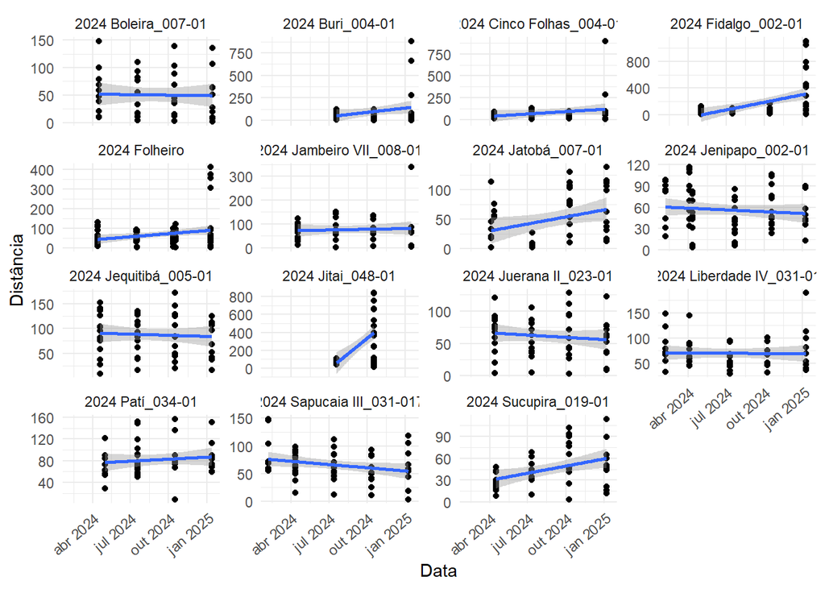

**Escala Relativa**

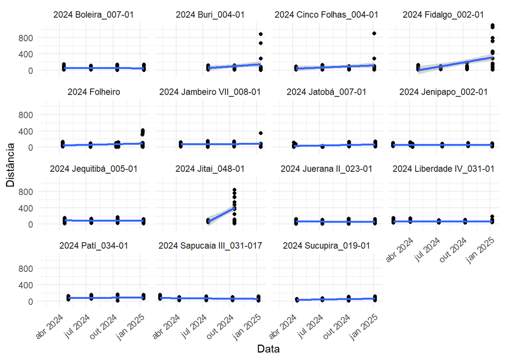

A tabela a seguir apresenta o crescimento (em verde) ou decrescimento (em vermelho) médio entre todas as amostras de fazenda, observado desde a primeira coleta até a ultima realizada, calculado com os outliers já retirados. Estes dados confirmam as informações anteriormente mencionadas que as fazendas Jitaí, Fidalgo e Folheiro obtiveram um incremento expressivo na distância de suas coletas.

As demais fazendas apresentaram um intervalo de diferença relativamente baixo, demonstrando constância nas distâncias necessárias para a transmissão dos dados.

| Fazenda | Crescimento Médio de Distância |
| --- | --- |
| 2024 Sapucaia III_031-017 | -24.272222 |
| 2024 Jenipapo_002-01 | -12.526162 |
| 2024 Juerana II_023-01 | -12.093409 |
| 2024 Jequitibá_005-01 | -10.976143 |
| 2024 Boleira_007-01 | -5.149636 |
| 2024 Liberdade IV_031-01 | -1.078889 |
| 2024 Buri_004-01 | 1.901154 |
| 2024 Jambeiro VII_008-01 | 8.122906 |
| 2024 Patí_034-01 | 13.775152 |
| 2024 Cinco Folhas_004-01 | 21.627273 |
| 2024 Sucupira_019-01 | 24.133182 |
| 2024 Jatobá_007-01 | 26.934167 |
| 2024 Folheiro | 80.834091 |
| 2024 Fidalgo_002-01 | 122.337222 |
| 2024 Jitai_048-01 | 206.876250 |

Por fim, a tabela a seguir demonstra as distâncias médias das últimas coletas para cada fazenda. Com estas informações, a distância média de coleta para o projeto total é de 86,51 m.

| Fazenda | Distância Média por Fazenda |
| --- | --- |
| 2024 Boleira_007-01 | 48.61400 |
| 2024 Sucupira_019-01 | 51.91500 |
| 2024 Juerana II_023-01 | 57.46889 |
| 2024 Sapucaia III_031-017 | 61.08556 |
| 2024 Jenipapo_002-01 | 61.20444 |
| 2024 Jatobá_007-01 | 73.85000 |
| 2024 Liberdade IV_031-01 | 74.01222 |
| 2024 Buri_004-01 | 77.14700 |
| 2024 Jequitibá_005-01 | 79.33667 |
| 2024 Folheiro | 80.62889 |
| 2024 Jambeiro VII_008-01 | 84.82444 |
| 2024 Cinco Folhas_004-01 | 87.02667 |
| 2024 Patí_034-01 | 87.89000 |
| 2024 Fidalgo_002-01 | 134.45700 |
| 2024 Jitai_048-01 | 238.12800 |